# Partial regression and partial residual plots

FW8051 Statistics for Ecologists

## Learning Objective

Understand approaches for visualizing fitted multiple regression models

## Visualizing Multiple Regression

$\beta_1$ reflects the “effect” of $X_1$ after accounting for $X_2$.

How can we visualize this “effect”?

- Added variable or partial plots
- Component + residual or partial plots

See the paper by Larano and Corcobado (2008) and Section 3.14 in the Book.

## Added Variable Plots (for $X_i$)

1. Regress $Y$ against $X_{-i}$ (i.e., all predictors *except* $X_i$), and obtain the residuals
2. Regressing $X_i$ against all other predictors ($X_{-i}$) and obtain the residuals
3. Plot the residuals from [1] against the residuals from [2].

Plots the part of $Y$ not explained by other predictors (i.e., $X_{-i}$) against the part of $X_i$ not explained by the other predictors ($X_{-i}$).

Lets us visualize the effect of $X_i$ after accounting for all other predictors.

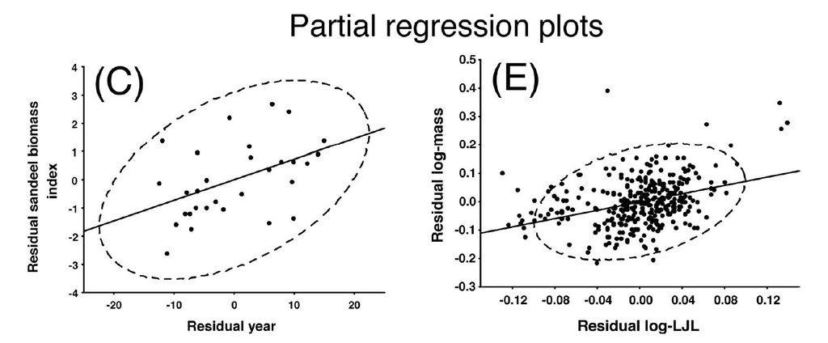

Shows the slope and the true scatter of points around the partial line in an analogous way to bi-variate plots in simple linear regression

## Added variable plot for $X_1$

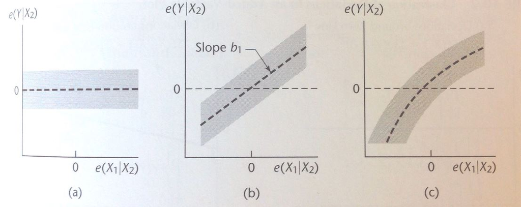

- Panel (a) suggests $X_1$ provides no additional information useful for predicting $Y$ beyond that contained in $X_2$
- Panel (b) suggest a linear relationship is appropriate (after accounting for $X_2$); the slope here is the same as that in the multiple regression model containing both $X_1$ and $X_2$
- Panel (c) suggests we may need to allow for a non-linear relationship between $X_1$ and $Y$

## Component + residual plots or partial residual plot

Plots $X_i\beta_i + \hat{\epsilon}_i$ versus $X_i$.

- Better for diagnosing non-linearities
- X-axis depicts the scale of the focal variable (rather than the scale residuals)
- Not as good at depicting the amount of variability explained by the predictor (given everything else in the model).
- Easy to generalize to other regression models (see visreg package on Canvas)

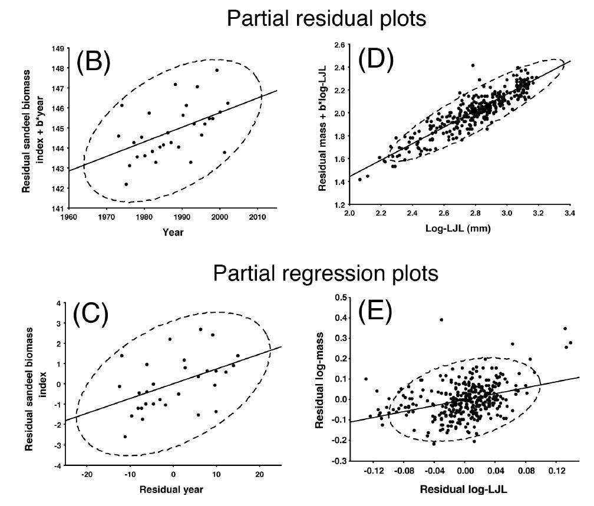

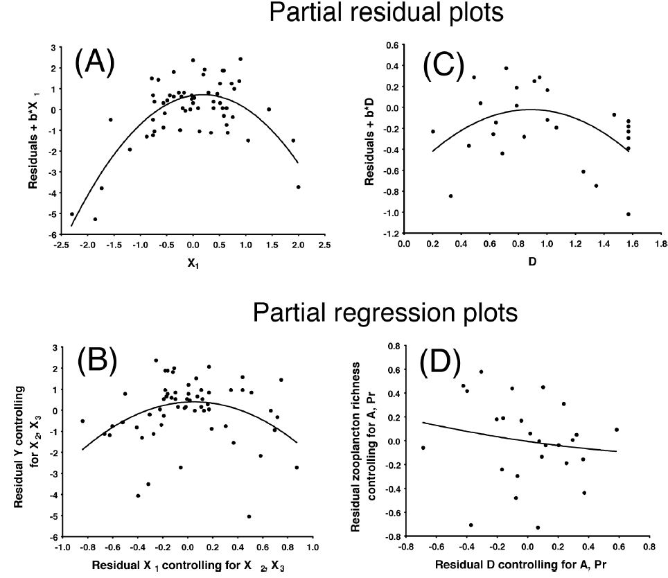

## Effect plots

See Section 3.14.3 in the Book. Consider a focal predictor $X_i$ and the set of all other predictors $X_{-i}$.

We can plot *adjusted means* by varying a focal variable over its range of observed values, while holding all non-focal variables at constant values (e.g., at their means or modal values).

Depict $E[Y_i | X_{-i} = x_{-i}]$ versus $X_i$.

Alternatively, we can plot marginal means. These are formed in much the same way, except that predictions are averaged across different levels of each categorical variable.

These two types of means are equivalent if there are no categorical predictors in the model.